Biostatistics · Statistical Programming · Data Science

# Assoc. Prof. PaedDr. RNDr. Stanislav Katina, PhD.

## Principal and Senior Principal-level biostatistician, statistical programming leader and R/R Shiny expert

I connect **statistical strategy**, **clinical-development evidence** and **modern analytical engineering**. Across 28+ years, I have designed studies, led statistical work, built reproducible systems and translated complex biomedical data into decisions.

Approximately **23.5 years of cumulative international experience**, combining long-term appointments abroad, 37 short-term research visits and work for international companies.

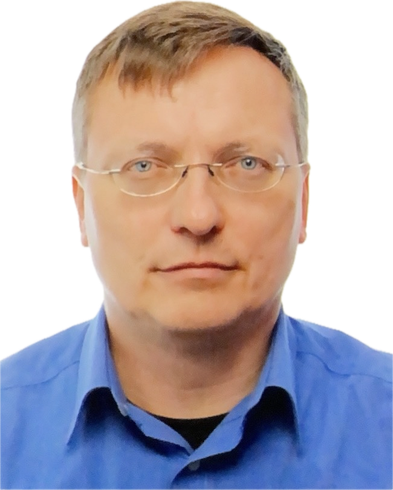

### Who I Am

I am a **Principal and Senior Principal-level biostatistician, statistical programming leader and quantitative scientist** who brings together scientific strategy and hands-on delivery. My perspective has been shaped by 28+ years across clinical development, preclinical and translational research, real-world evidence, statistical methodology, software development and university teaching. I work from the scientific question through design, data, analysis and interpretation—building evidence that is rigorous, reproducible and useful.

**International professional leadership:** [Treasurer and Officer of the International Society for Clinical Biostatistics (ISCB)](https://iscb.international/executive-committee/) and [Chair of its Statistics in Regulatory Affairs Subcommittee](https://iscb.international/statistics-in-regulatory-affairs/).

[LinkedIn](https://cz.linkedin.com/in/stanislav-katina-95213a65) [GitHub](https://github.com/stanislavkatina) [ISCB](https://iscb.international/)

28+

years in programming and biomedical statistics

23.5

years of cumulative international experience

long-term appointments abroad · 37 short-term research visits · international companies

31

clinical, RWE, registry and representative preclinical studies/programs

I–IV

clinical phases, plus preclinical research and RWE

130+

peer-reviewed publications

**2,044** Scopus citations · **1,639** Web of Science citations

## My Experience, Connected

The strongest part of my profile is not any single method or technology, but the way the elements work together—from scientific question and study design to validated data, reproducible analysis, interpretation and decisions.

[figure not shown]

**Clinical Development**Phase I–IV · RWE · design · SAPs · estimands **Statistical Programming**SDTM · ADaM · TLFs · SAS · R · validation **R & Shiny**Applications · Quarto · packages · interactive reporting **Research & Publications**Neuroimmunology · biomarkers · shape · imaging · methodology **Leadership & Strategy**ISCB · SiRA · modernization · teaching · mentoring

## What I bring

### Clinical-development leadership

Study design, protocol and SAP strategy, Bayesian simulations, dose escalation, estimands, safety and efficacy analyses, PK/PD, biomarkers and scientific reporting.

Clinical portfolio →

### Statistical programming leadership

Programming-ready SAPs, SDTM and ADaM review and programming, TLF development and validation, SAS-to-R validation, pooled analyses and traceable reporting.

Programming expertise →

### Modernization with R and Shiny

End-to-end R workflows, R Shiny applications, interactive HTML reports, patient profiles, Quarto publications, SQL/SQLite integration, Azure and GitLab-supported delivery.

Selected work →

### Research and academic leadership

Neuroimmunology, neurodegeneration, biomarkers, omics, statistical shape analysis, teaching, supervision and international collaboration.

Research profile →

## Professional focus

My recent work spans global Phase III and real-world programs in immunology, autoimmune and inflammatory disease, nephrology, dermatology and allergology. Earlier leadership includes Phase I–II oncology and immuno-oncology, tau-immunotherapy studies in neurodegeneration, clinical pharmacology, vaccines, cardiovascular research and registry-based evidence.

I work at the intersection of biostatistics and statistical programming: shaping an analysis so that it is scientifically defensible, implementation-ready, reproducible and useful to clinical and medical teams.